# Module 3 group work

```r
library(ggplot2) #load ggplot
library(ggthemes) #load themes package for ggplot
theme_set(theme_tufte()) # a theme I like.

#set some options that I like
theme_update(plot.title = element_text(hjust = 0.5),
             axis.line.x = element_line(color="black", size = 1),
             axis.line.y = element_line(color="black", size = 1),
             text=element_text(size=20),
             axis.text=element_text(size=15)) #center all titles and and axis lines
```

We can use the function `sample` to randomly draw numbers from a set. We can draw with replacement (`replace=TRUE`) or without (`replace=FALSE`). 1. create a vector of values from 1 to 25. 2. randomly sample 10 values with replacement from this vector. Calculate the mean and standard deviation. 3. randomly sample 10 values without replacement from this vector. Calculate the mean and standard deviation. 4. Repeat 2 but sample 1000 values with replacement. Calculate the mean and standard deviation. Are they similar?

```r
#code here
x <- 1:25

replace <- sample(x, size=10, replace=TRUE)
woreplace <- sample(x, size=10, replace=TRUE)

mean(replace)
```

```
[1] 9.7
```

```r
sd(replace)
```

```
[1] 7.379401
```

```r
mean(woreplace)
```

```
[1] 14
```

```r
sd(woreplace)
```

```
[1] 8.881942
```

```r
replacethou <- sample(x, size=1e3, replace=TRUE)
mean(replacethou)
```

```
[1] 13.088
```

```r
sd(replacethou)
```

```
[1] 7.215284
```

Here is another example of using for loops. We will loop through some of the columns of a dataset on silverswords and calculate the mean of each column. We will explore what each of these columns mean in a future module.

```r
silver.dat <- read.csv(file="../Data/Silversword.csv")
for(i in 1:6) {
  print(mean(silver.dat[,i], na.rm=TRUE))
}
```

```
[1] 2443.935
[1] 1204.032
[1] 3.954839
[1] 919.0968
[1] 482.5806
[1] 436.5161
```

**Excercise** Update the below for-loop from above to store the mean value for each column in the dataset. I’ve given you most of the code but you will need to store each mean value in the vector `mean.silver`.

```r
# Update this code
mean.silver <- numeric(6)
for(i in 1:6) {
  mean.silver[i] <- mean(silver.dat[,i], na.rm=TRUE)
}
mean.silver
```

```
[1] 2443.935484 1204.032258    3.954839  919.096774  482.580645  436.516129
```

Now lets take the code from the first exercise (e.g., `sample(x=1:25, size=10, replace=TRUE)`) and put it inside the following `for` loop. Once the code is pasted in there take the mean of the sample and assign that value to the `i`ith value of mean.vec.

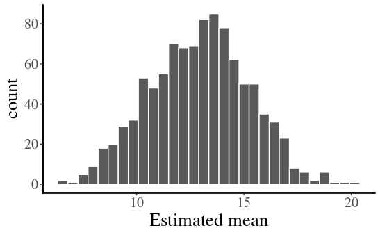

```r
mean.vec <- numeric(1e3)
for (i in 1:length(mean.vec)) {
#code here
  mean.vec[i] <- mean(sample(x=1:25, size=10, replace=TRUE))
} #basic for loop


#plots the resulting mean estimates
ggplot() +
  geom_histogram(aes(x=mean.vec), col="white") + xlab("Estimated mean")
```

```r
#code here
beer.dat <- read.csv(file="../Data/BeerGlassShape.csv")

obs.val <- mean(beer.dat$drinkingMinutes[1:10]) - mean(beer.dat$drinkingMinutes[11:19])
print(obs.val)
```

```
[1] 7.319667
```

```r
null.vec <- numeric(1e4) #scientific notation for 10000
for(i in 1:1e4) {
  index       <- sample(1:19, 10, replace=F)
  null.vec[i] <- mean(beer.dat$drinkingMinutes[index]) - mean(beer.dat$drinkingMinutes[-index])
}

p.val <- 2*sum(null.vec > obs.val)/length(null.vec)

print(p.val)
```

```
[1] 0.0034
```

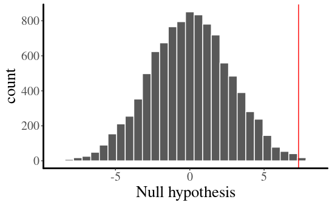

```r
ggplot() +
  geom_histogram(aes(x=null.vec), col="white") + xlab("Null hypothesis") +
  geom_vline(aes(xintercept=obs.val), col='red')
```

### Based on the randomization test it would be extremely rare for the observed difference to occur if there was no difference in the average drinking time between the glasses.